# Prisoner Injustices: Incarceration Injustices in the US from 1970-2018

Collin Shen

2022-11-01

## Abstract

The Incarceration trends in the US since 1970 reveal inequality disparities in the American justice system. Although many policies related to crime and incarceration have been changed throughout the decades and many areas in the US have had lots of changes, incarceration in the US still remains incredibly high. My report will examine historical incarceration trends and potential inequalities. This report can help to bring potential inequalities to light.

## Introduction

Jailing and imprisonment in the United States contains lots of systemic injustices and inequalities. During the 1970s and 1980s, the national commitment to “tough on crime” fought fire with fire. Convicts were heavily prosecuted and sentenced to longer terms under pressure to crack down on criminals. Lower-level felony incarceration increased, and over-policing overwhelmed courts across America. Bill Clinton continued the tradition established by former presidents by passing the largest crime bill in American history. He increased funding for prisons and police, and he prevented incarcerated people from receiving Pell Grants. What effect did these policy changes have on the incarceration rates in the US? This report seeks to shed light on the consequences of America’s past in order to better inform our future. By the early 2000s, it was clear that mass incarceration was wreaking havoc on entire communities. Black people continue to be incarcerated at a rate that is more than twice that of white people. Black neighborhoods are still over-policed, and black people are still overcharged in courts across the country. However, the consequences of mass incarceration reach far beyond America’s prison walls, as well as our police and courts. Mass incarceration has wreaked havoc on families, communities, and futures.After all, how we treat our incarcerated population reflects not only individual rights but, more fundamentally, America’s priorities. To understand how to proceed, we must first understand how America’s priorities have historically defined Jailing.

## Data Summary

Between the years of 1970 and 2018, 1993 had the highest total jailing population in all of America which was in Los Angeles County.

Between the years of 1970 and 2018, 1993 had the highest total jailing population for male juveniles in all of America which was in New York County.

## Section 3

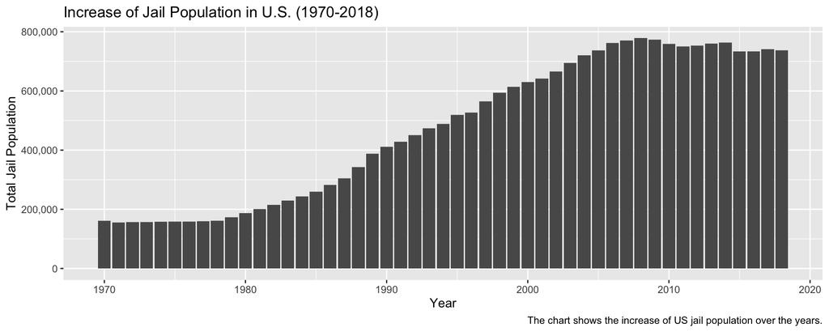

## Section 4: Growth of Prison Population by State

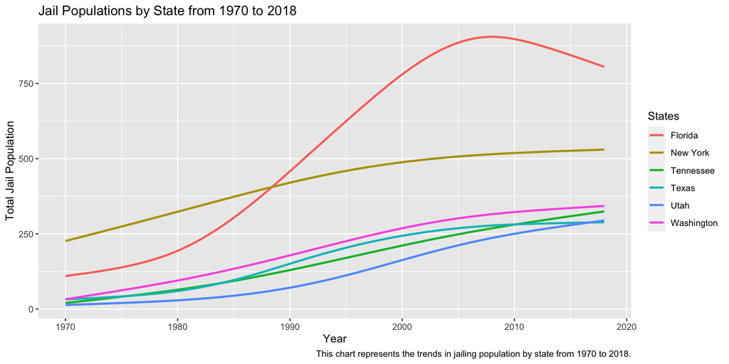

The six states chosen represent different regions of the US. Some of the state’s prison population growth patterns were distinct. 4 of the states which were, Washington, Utah, Texas, and Tennessee had very similar trends. This implies that the “tough on crime” era was implemented differently at the state level. New York had a steadily high level of jail population and Florida had a drastic increase after around 1983. This raises the question: which policies had a large impact on the state’s prison population growth over the years?

## Section 5: Male Juvenile Jailing rates by region in the US

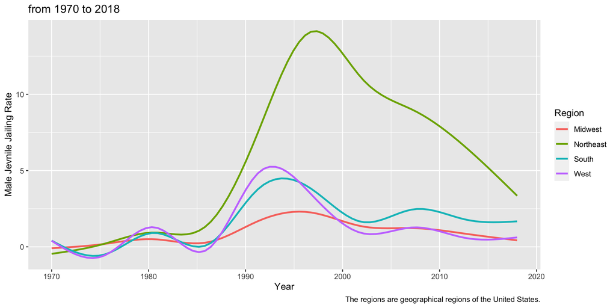

The four regions chosen represent the different regions of the US defined by the Vera project. We can see that all 4 regions hold a similar general shape with a spike of male juvenile jailing rates around the year 1995. We can also see that the Northeast region has a huge spike that is different from the rest. This brings up the question: What happened to counties specefically in the northeast to cause such a big spike in incarceration of Male Juveniles?

## Section 6: Male Juvenile Jailing rates by State

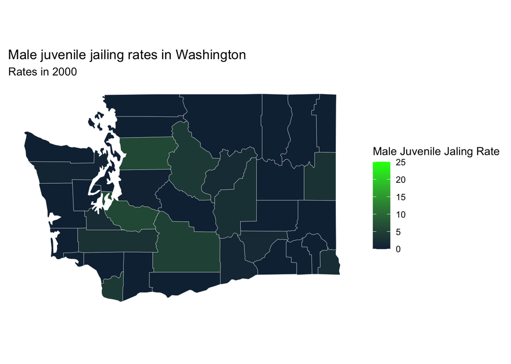

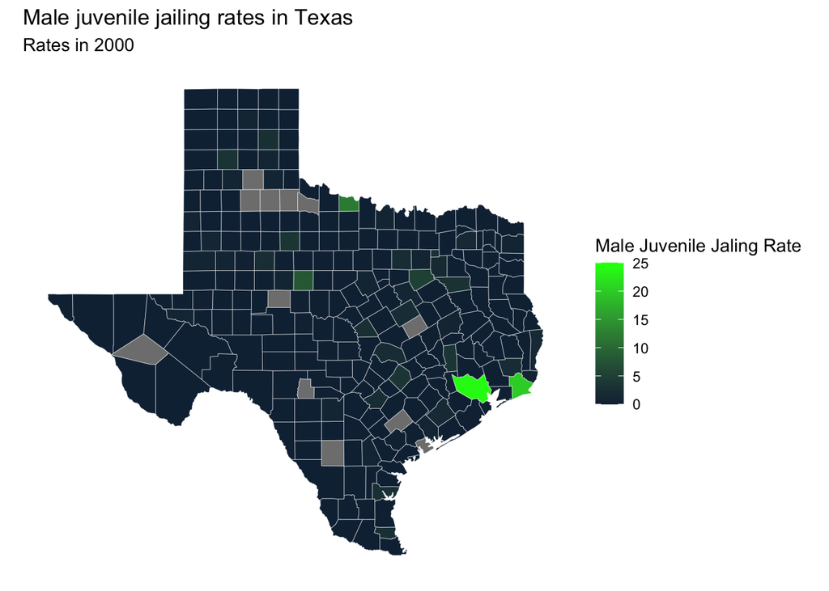